# Lecture 1:Opening R for the first time

09 August 2017

# 1 Installing R for the first time!

## 1.1 About R

R is free, open-source software, available for all commonly used operating systems, including Windows, Mac OS X, and Linux systems. You can download it form the web-site [CRAN](https://cran.r-project.org/).

**IMPORTANT: Regardless of your operating system, you should install R before installing RStudio.**

**IMPORTANT: R is case and character sensitive language**

# 2 RStudio

RStudio is an integrated development environment (IDE) for R which works with the standard version of R higher than version 2.11. available from RStudio web-site [RStudion](https://www.rstudio.com/products/rstudio/download/). Source editor for writing scripts, workspae to view objects in the global environment, dataviewer for inspecting elements, searchable command history, plots pane, Rpackage manager, Integrated R help

[figure not shown]

RStudio RMarkdown first screen!

In Console window you can clearly see the exact version of R software like one on machine that created this Rnotebook (R version 3.3.2 (2016-10-31) – “Sincere Pumpkin Patch”). Executive R code is written within Chunk!

## 2.1 RStudio session

You have to take care about two things within RStudio session:

1.RObjects created within session

2.RScripts written for particular session - in this case RMarkdown!

## 2.2 Prompt change

You can easily change your default prompt (>) in R to something else like RStudio>:

```r
options(prompt="RStudio>")
```

If you want to set it back use:

```r
options(prompt=">")
```

## 2.3 Keyboard shortcuts

| Description | MAC | PC |
| --- | --- | --- |
| Navigate command (last) | $\uparrow$ | $\uparrow$ |
| Navigate command (next) | $\downarrow$ | $\downarrow$ |
| Last matching command | CMD + $\uparrow$ | CTRL + $\uparrow$ |
| TAB completion | TAB | TAB |
| Dismiss completion popup | Esc | Esc |

## 2.4 Setting working directory

If you are not using RProject default working directory could be set as follows:

First go to Tools and Global options as shown on the picture:

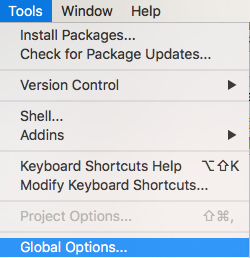

RStudio Tools Global Options!

Then you change RGeneral default working directory (black rectangle), press apply and OK.

[figure not shown]

RStudio Tools Working directory!

To check it you can type in:

```r
getwd()
```

# 3 Basic calculations - use RStudio as a calculator

You can use RStudio to perform basic calculations: addition, subtraction, division, multiplication, exponents and modulo.

Addition

```r
2+7
```

```
## [1] 9
```

Subtraction

```r
11-3
```

```
## [1] 8
```

Division

```r
18/3
```

```
## [1] 6
```

Multiplication

```r
5*8
```

```
## [1] 40
```

Exponents

```r
2^4
```

```
## [1] 16
```

But be carefull if you want to write 2 to the power of 3 minus 1, i.e. 2 to the power of 2, while you have to put this number in parentheses: Good example:

```r
2^(3-1)
```

```
## [1] 4
```

Otherwise you get 2 to the power of 3 and then minus 1 because R follows the [operator precedence rule](https://en.wikipedia.org/wiki/Order_of_operations):

```r
2^3-1
```

```
## [1] 7
```

**Carefull with negative numbers**, while R considers a negative number -2 as -1*2, therefore you need parenthese around (-2).

Modulo operation finds the remainder after division of one number by another (sometimes called modulus). In this example 5 divided by 2 is 2 and the remainder is 1.

```r
5 %% 2
```

```
## [1] 1
```

You can also transfer a bit complicated formula
$$(\frac{0.14 * (1-0.14)}{24})^{1/3}$$
to a R executable code:

```r
(0.14*(1-0.14)/24)^(1/3)
```

```
## [1] 0.1711874
```

## 3.1 Assignment 1

1. Calculate in RStudio following expression for x=3:
   $$\frac{2x +51}{3^{-4.2+5.62}} = ?$$
2. What is the solution for negative number five squared and added number two?

Solution 1:

```r
x<-3
(2*x+51)/3^(-4.2+5.62)
```

```
## [1] 11.9774
```

Solution 2:

```r
(-5)^2+2
```

```
## [1] 27
```

# 4 R Objects

## 4.1 Comments

Comments are important in R and they start after hash mark (#). This kind of annotation could be usefull other people using your code!

```r
#This is a comment
2+2 #Example of addition
```

```
## [1] 4
```

A good rule is to always write at least one line of comment for every line of code. You need to be kind to “future you” so that “future you” is happy with “present you” a few months down the line when you need to analyse that dataset again.

## 4.2 Assigning and removing R Objects

Suppose we want to give a object called `a` the value of 53. We can perform that by writting following code in R Markdown:

```r
a <- 53
```

We can check if our object exists with typing its name.

```r
a
```

```
## [1] 53
```

To check if our object exist in R working environment we can use list function ls().

```r
ls()
```

```
## [1] "a" "x"
```

To remove object a from the R working environment we can use remove function rm().

```r
rm(a)
```

After we remove our object from R environment we can check our list of objects with list function.

```r
ls()
```

```
## [1] "x"
```

Our previously created object `a` is not available in R environment anymore.

# 5 Functions

## 5.1 Assigning R Objectes with combine function

Suppose we want to make one object with house mouse body weight. We can use **combine** function to do that. Example: `mouse.wts <-c()`. In brackets are measurements divided by comma.

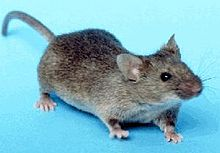

House mouse!

Photo source: [House mouse](https://en.wikipedia.org/wiki/House_mouse)

```r
rm(list = ls()) #clearing the environment of any left over objects from a previous analysis
mouse.wts <-c(16.6, 12, 10.9, 15.9, 25, 14.5, 18.2, 13.8, 21, 21.5) #creating a vector with house mouse body weight in grams
```

## 5.2 Class function

The `class` function can be used to determine class of particular object. R has 5 basic atomic classes

```
logical (e.g.,RUE, FALSE)
integer (e.g., 1L, 2L)
numeric (real or decimal) (e.g, 2, 2.0, pi)
complex (e.g, 1 + 0i, 1 + 4i)
character (e.g, "a", "b")
```

Suppose we want to check what class has object mouse.wts.

```r
class(mouse.wts)
```

```
## [1] "numeric"
```

The `str` function is also useful as it returns a summary of the structure of the object, including information on what class and dimension the object contains.

```r
str(mouse.wts)
```

```
##  num [1:10] 16.6 12 10.9 15.9 25 14.5 18.2 13.8 21 21.5
```

# 6 Summary Statistics

Some basic functions (mean, min, max, summary) to caluculate from both samples

## 6.1 Mean function

The arithmetic mean is a quantitative measure of central tendency that is highly sensitive to outliers. The value of the aritmentic mean is in same units as original variable! To calculate the arithmentic mean in R we use following code:

```r
mean(mouse.wts)
```

```
## [1] 16.94
```

## 6.2 Min function

The minimum function returns the smallest (nearest to negative infinity) value in the vector.

```r
min(mouse.wts)
```

```
## [1] 10.9
```

## 6.3 Max function

The maximum function returns the largest (nearest to positive infinity) value in the vector.

```r
max(mouse.wts)
```

```
## [1] 25
```

# 7 Which entries are the smallest or largest?

The related function `which.min()` and `which.max()` will tell us the index of the entry in the vector that is the smallest or largest:

```r
idx_min <- which.min(mouse.wts)

# the entry in the vector with the smallest value is
print(idx_min)


# = = = = = = = = = = = = = = = = = = = = = = = = = = = = = =

idx_max <- which.max(mouse.wts)

# the entry in the vector with the largest value is
print(idx_max)

# and then we can recover the smallest and largest values just to check
c(mouse.wts[idx.min], mouse.wts[idx.max])
```

[output not shown]

## 7.1 Summary function

Summary function gives you a set of descriptive statistics for the analyzed vector.

```r
summary(mouse.wts)
```

```
##    Min. 1st Qu.  Median    Mean 3rd Qu.    Max.
##   10.90   13.97   16.25   16.94   20.30   25.00
```

## 7.2 Help function in R

If we need help on any function in R we could write down ?name of the function and help(name of the function in brackets)

```r
?summary
help(summary)
```

# 8 Figures in R

## 8.1 Plot

If we have a single variable then R makes a plot of the values of x (on the y-axis) ordered on the x-axis with Index from first to last value.

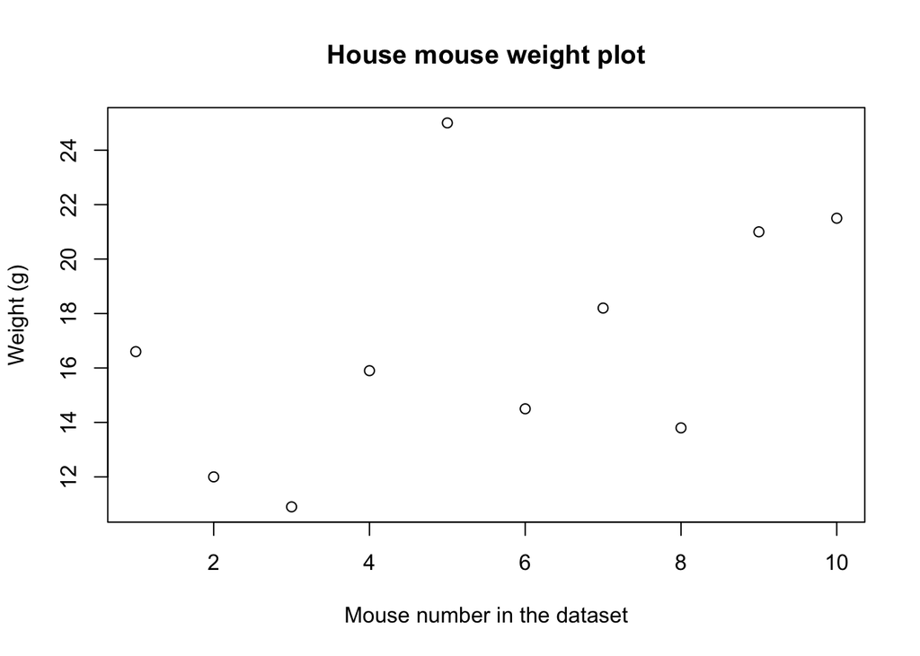

```r
plot(mouse.wts, main="House mouse weight plot", xlab="Mouse number in the dataset", ylab="Weight (g)")
```

## 8.2 Histogram

A histogram is a visual representation of the distribution of a dataset. If we want to see a histogram of the data we could use hist function:

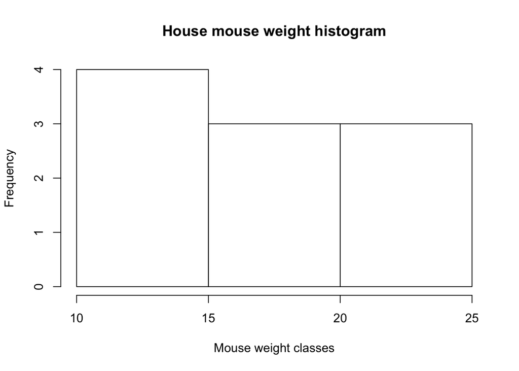

```r
hist(mouse.wts, main="House mouse weight histogram", xlab="Mouse weight classes", ylab="Frequency")
```

## 8.3 Box plot

Syntax for boxplot in first case is boxplot(variable_name) and in the second case boxplot(x, data=), where x is a variable name or formula and data= dataframe that provides the data.

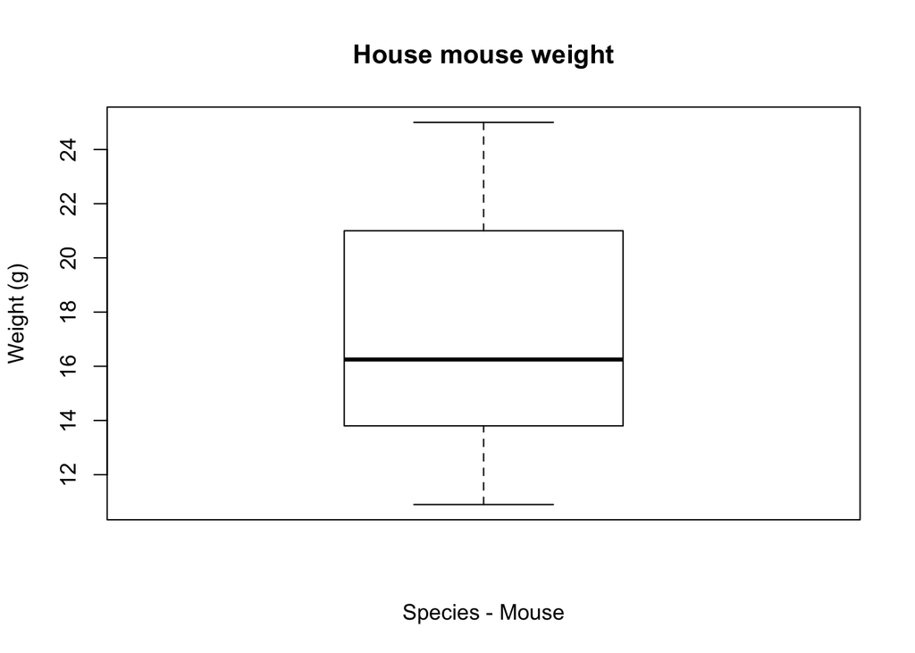

```r
boxplot(mouse.wts, main="House mouse weight", xlab="Species - Mouse", ylab="Weight (g)") #boxplot for the variable mouse.wts
```

## 8.4 Assignment 2

1. Plot a function Z using plot function with option type =“l” to plot line instead of points:

$$Z= x^3 -6x^2+4x+12$$
For x values use a sequence of numbers between an arbitrary range of `-2.1` and `6.1` with increment `0.1`. (Hint: Use seq function; seq function arguments: inital value, final value and increment)

Solution 1:

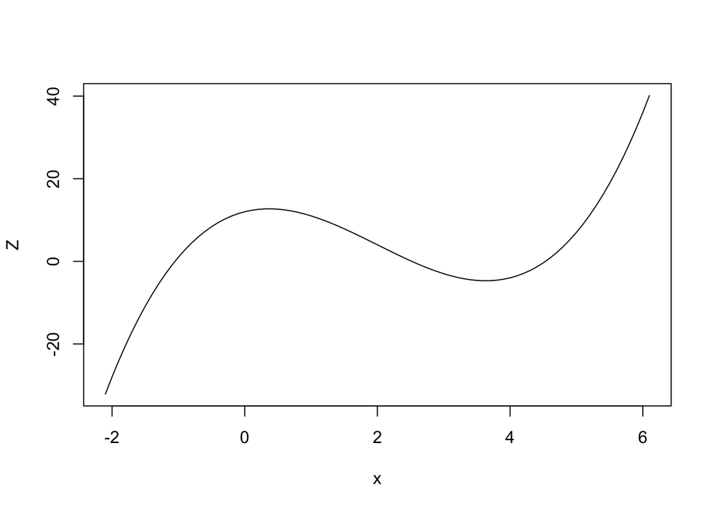

```r
x<-seq(-2.1,6.1,0.1)
Z<- (x^3-6*x^2+4*x+12)
plot(x,Z, type="l")
```

2. Now try to plot the same function and call it Z1 with increment for x instead by 0.1 to 1.

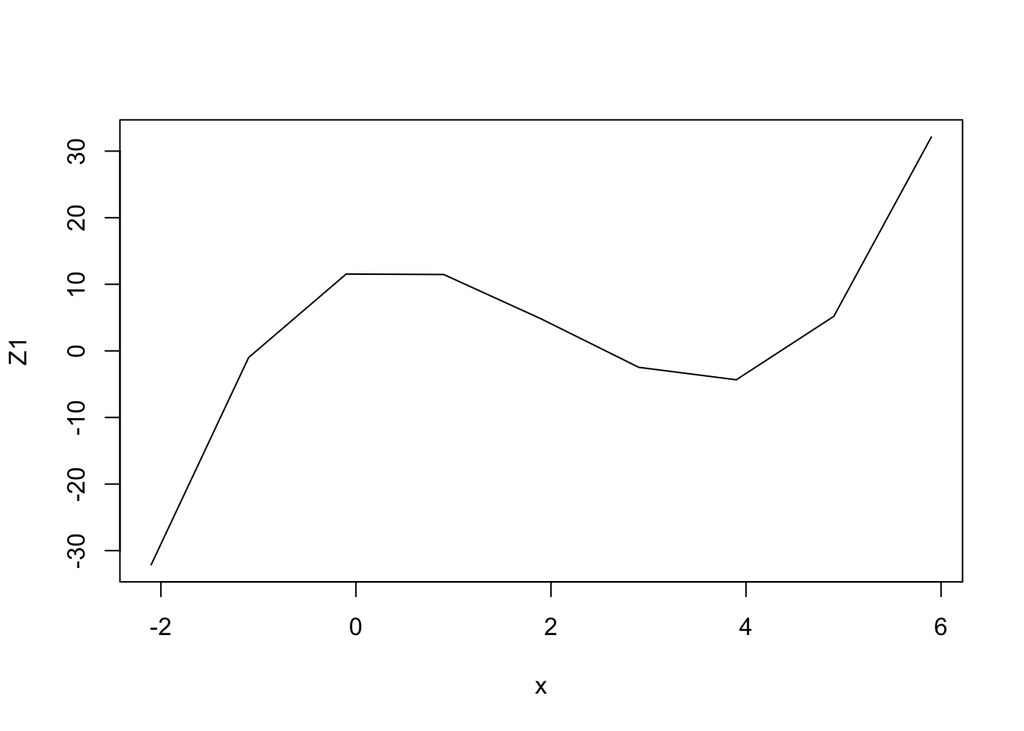

```r
x<-seq(-2.1,6.1,1)
Z1<- (x^3-6*x^2+4*x+12)
plot(x,Z1, type="l")
```

What is the difference in plots?!

If you want to learn more about nice graphs take a look at the package [ggplot2](http://ggplot2.org/)!